# CMS Open Payments

Benjamin Chan (chanb@ohsu.edu)

**Play around with the CMS [Open Payments](http://www.cms.gov/OpenPayments) data.**

2014-10-04 13:24:37

R version 3.1.1 (2014-07-10)

# Get the data

Run the script to read the data. Hide the code and the output since it’s under version control on [GitHub](https://github.com/benjamin-chan/OpenPayments). Also, source a function library.

```r
setwd(file.path("~", "GitHub Repositories", "OpenPayments"))
source("library.r")
source("getData.r")
```

Use [OpenRefine](http://openrefine.org/) to clean the data. This requires an interactive session of OpenRefine.

# Mapping payments

**Which states received the most payments?** Map payments at the state level.

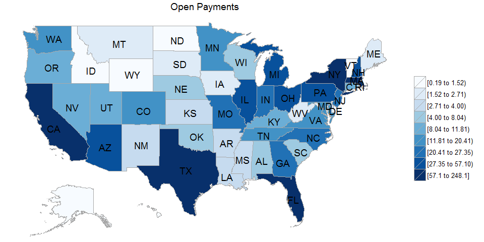

```r
DAgg <- D[,
          list(value = sum(amount) / 1E6,
               region = Recipient_State),
          list(Recipient_State)]
require(choroplethr)
choroplethr(DAgg,
            lod="state",
            title="Open Payments")
```

# Network of payers and recipients

## Select recipients

The network of payers and recipients is huge. Narrow the focus to **include only the following recipients**

- OHSU
- City of Hope National Medical Center
- Dana Farber Cancer Institute
- Burkhart, Stephen

Further narrow the focus to **include payers who made more than $10,000 in payments** to those recipients.

```r
DAgg <- D[,
          list(sumAmt = sum(amount)),
          list(payer, recipient)]
regex <- "OREGON HEALTH|CITY OF HOPE|DANA FARBER|BURKHART, STEPHEN"
DSubset <- DAgg[grepl(regex, toupper(recipient))]
DSubset <- DSubset[grep("OREGON HEALTH", toupper(recipient)), recipient := "OHSU"]
DSubset <- DSubset[grep("CITY OF HOPE", toupper(recipient)), recipient := "City of Hope"]
DSubset <- DSubset[grep("DANA FARBER", toupper(recipient)), recipient := "Dana Farber"]
DSubset <- DSubset[grep("BURKHART, STEPHEN", toupper(recipient)), recipient := "Burkhart, Stephen"]
DSubset <- DSubset[,
                   list(sumAmt = sum(sumAmt)),
                   list(payer, recipient)]
DSubset <- DSubset[sumAmt > 1E4]
DSubset <- DSubset[order(recipient, payer)]
DSubset[, list(sumAmtMillions = sum(sumAmt) / 1E6), recipient]
```

```
##            recipient sumAmtMillions
## 1: Burkhart, Stephen          7.353
## 2:      City of Hope        124.188
## 3:       Dana Farber         15.998
## 4:              OHSU          5.322
```

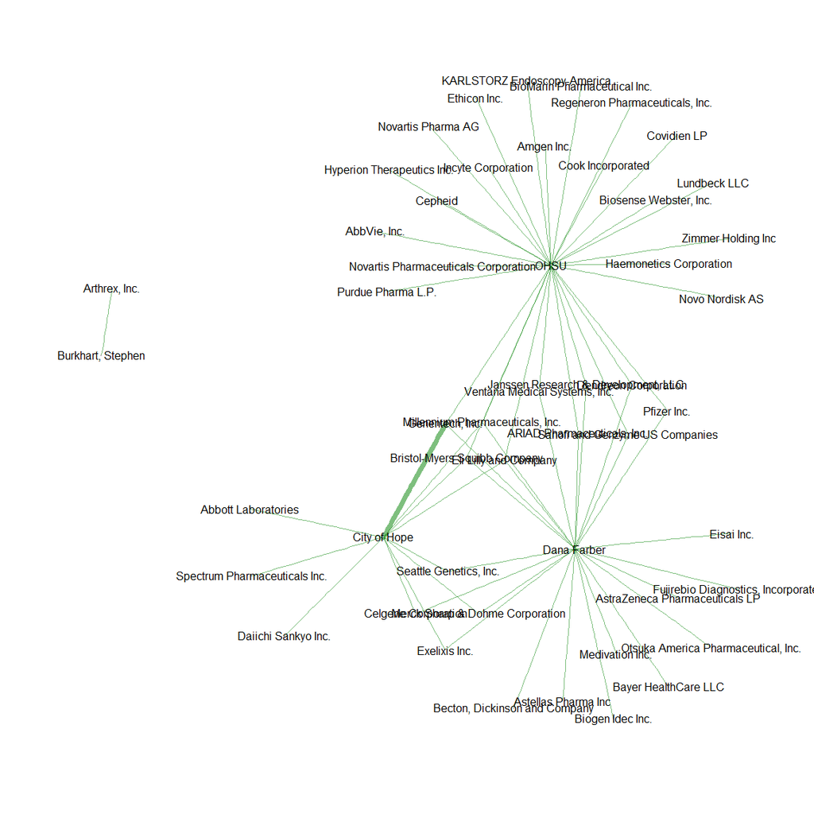

```r
require(igraph)
G <- graph.data.frame(DSubset, directed=FALSE)
V(G)$size <- 0
V(G)$color <- "grey"
E(G)$width <- scale(DSubset$sumAmt, center=FALSE, scale=TRUE)
E(G)$color <- rgb(0, 128, 0, 128, maxColorValue=255)
plot(G,
     vertex.label.color="black",
     vertex.label.family="sans",
     vertex.frame.color=NA)
```

## Big payments

Include payment of more than $100,000.

Create a graph for the entire network.

```r
D[,
  list(n = .N,
       sumAmtMillions = sum(amount) / 1E6),
  amtCategory][,
               list(amtCategory,
                    n,
                    pct = n / sum(n) * 100,
                    sumAmtMillions,
                    pctSumAmt = sumAmtMillions / sum(sumAmtMillions) * 100)][order(amtCategory)]
```

```
##      amtCategory       n       pct sumAmtMillions pctSumAmt
## 1:         [0,1]   26508 9.990e-01        0.01554  0.001386
## 2:        (1,10]  350839 1.322e+01        1.90670  0.170066
## 3:      (10,100] 1910119 7.199e+01       45.35024  4.044965
## 4:   (100,1e+03]  264241 9.958e+00       72.09519  6.430452
## 5: (1e+03,1e+04]   93982 3.542e+00      241.32082 21.524347
## 6: (1e+04,1e+05]    6718 2.532e-01      192.23733 17.146399
## 7: (1e+05,1e+06]     927 3.494e-02      223.39459 19.925437
## 8: (1e+06,1e+07]      94 3.543e-03      237.39911 21.174554
## 9:            NA       3 1.131e-04      107.43329  9.582395
```

```r
DAgg <- D[amount > 1E5,
          list(sumAmtMillions = sum(amount) / 1E6),
          list(payer, recipient)]
DAgg <- DAgg[,
             `:=` (sumAmtCategory = cut(sumAmtMillions, c(1E-1, 1E0, 1E1, 1E2, 1E3), include.lowest=TRUE),
                   sumAmtScaled = scale(sumAmtMillions, center=FALSE, scale=TRUE))]
DAgg[,
     list(n = .N,
          sumAmtMillions = sum(sumAmtMillions)),
     sumAmtCategory][order(sumAmtCategory)]
```

```
##    sumAmtCategory   n sumAmtMillions
## 1:        [0.1,1] 686          185.2
## 2:         (1,10]  67          143.1
## 3:       (10,100]   4          118.0
## 4:    (100,1e+03]   1          121.8
```

```r
vertices <- rbind(unique(DAgg[, list(name = payer, type = "Payer")]),
                  unique(DAgg[, list(name = recipient, type = "Recipient")]))
G <- graph.data.frame(DAgg, vertices=vertices, directed=TRUE)
V(G)$size <- 0
V(G)$color <- ifelse(V(G)$type == "Payer", "red", "black")
E(G)$color <- rgb(0, 128, 0, 128, maxColorValue=255)
E(G)$weight <- unclass(DAgg$sumAmtCategory)
E(G)$width <- unclass(DAgg$sumAmtCategory)
```

Plot the network. Get the file at [./OpenPayments_files/figure-html/networkBigPayments.png](https://github.com/benjamin-chan/OpenPayments/blob/master/OpenPayments_files/figure-html/networkBigPayments.png) for the full effect.

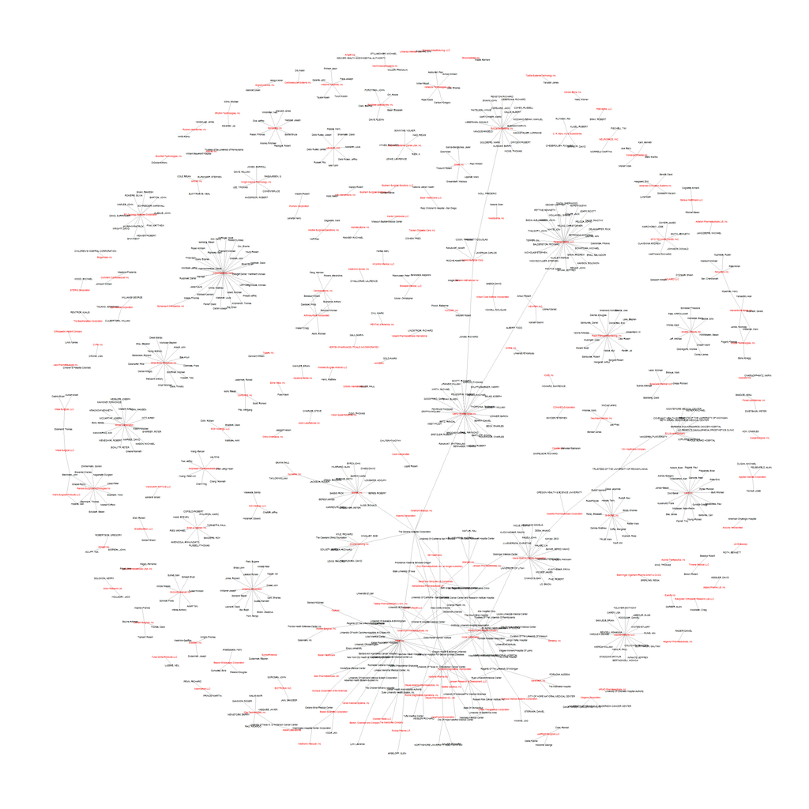

```r
plot(as.undirected(G),
     vertex.label.cex=0.5,
     vertex.label.color=V(G)$color,
     vertex.label.family="sans",
     vertex.frame.color=NA)
```

Write GraphML dataset for use in [Gephi](http://gephi.github.io/).

```r
write.graph(G, file.path(getwd(), "openpayments.graphml"), format="graphml")
```